# Machine Learning - Predicting exercise execution type

Martin Bühler, Feb 15, 2022

# 1 Management summary

In this project we use data from accelerometers on the belt, forearm, arm, and dumbell of 6 participants. The participants were asked to barbell lifts correctly and incorrectly in 5 different ways and we want to predict in which of the 5 manners the exercise was done.

Because the outcome is a factor variable we look at predicting with trees, random forests and boosting. The best option turns out to be the random forest algorithm where we can achieve an accuracy of over 0.99 and therefore an expected out of sample error of less than 1%.

We can confirm that with both, the random forest and boost algorithm (with 0.632 Bootstrap for cross validation), we have the same prediction on the test set. Which also serves as further cross validation evidence on the accuracy of our model.

# 2 Cleaning of data

## 2.1 Data inspection

First of all, the relevant libraries for this project are loaded, the training data is stored in the data frame df.training and the test data is imported in the data frame df.testing.

```r
# Initialize libraries
library(caret)
library(rattle)
library(randomForest)
library(gbm)
library(ggplot2)

# Extract the data
df.training <- read.csv2("pml-training.csv", sep = ",", header = TRUE)
df.testing <- read.csv2("pml-testing.csv", sep = ",", header = TRUE)
```

## 2.2 Data inspection

```r
# Inspect the data
str(df.training, list.len=ncol(df.training))
colSums(is.na(df.training) | df.training == "")
```

[output not shown]

## 2.3 Data cleaning

The following code is implementing the findings as observed in the chapter “2.2 Data inspection”. The resulting data frames keep the same name.

```r
# Drop columns with many invalid entries
df.training <- df.training[ ,colSums(is.na(df.training) | df.training == "") == 0]
df.testing <- df.testing[ ,colSums(is.na(df.testing) | df.testing == "") == 0]
# Change data type of string columns to

# Drop descriptive columns
df.training <- df.training[, 8:ncol(df.training)]
df.testing <- df.testing[, 8:ncol(df.testing)]

# Convert columns to numeric
df.training[, c(1:(ncol(df.training)-1))] <- sapply(df.training[, c(1:(ncol(df.training)-1))], as.numeric)
df.testing[, c(1:(ncol(df.testing)-1))] <- sapply(df.testing[, c(1:(ncol(df.testing)-1))], as.numeric)

# Convert last column to factor column in training set
df.training$classe <- as.factor(df.training$classe)
```

# 3 Machine learning algorithms

## 3.1 Predicting with trees

First we try Predicting with trees, an algorithm which is relatively efficient.

[figure not shown]

```r
fit <- train(classe ~ . , method="rpart", data=df.training)
fancyRpartPlot(fit$finalModel)
```

It turns out that in the final model not all factors of the classe variable are present. The variable D is not showing up in the decision tree and therefore we have to find another prediction algorithm.

Nevertheless its useful to look at the boxplots to better understand the variables that indeed showed up in the decision tree and we can observe quite a big difference between the classes for some of the variables.

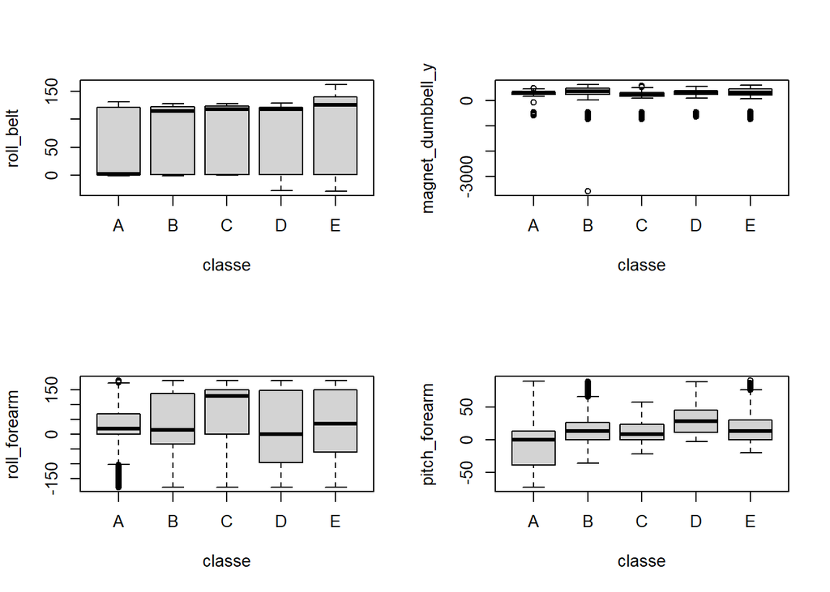

```r
par(mfrow=c(2,2))
plot(df.training[c(ncol(df.training),1)])
plot(df.training[c(ncol(df.training),38)])
plot(df.training[c(ncol(df.training),40)])
plot(df.training[c(ncol(df.training),41)])
```

## 3.2 Random Forests and Boosting

The following code is training on the Random Forest and Boosting algorithm and showing their respective output.

```r
fitControl <- trainControl(method = "boot632", number = 1, summaryFunction=defaultSummary)
fit.rf <- train(classe ~ ., method="rf", metric='Accuracy', trControl = fitControl, data=df.training)
fit.gbm <- train(classe ~ ., method="gbm", metric='Accuracy', trControl = fitControl, data=df.training, verbose=FALSE)
fit.rf
```

```
## Random Forest
##
## 19622 samples
##    52 predictor
##     5 classes: 'A', 'B', 'C', 'D', 'E'
##
## No pre-processing
## Resampling: Bootstrapped (1 reps)
## Summary of sample sizes: 19622
## Resampling results across tuning parameters:
##
##   mtry  Accuracy   Kappa
##    2    0.9966652  0.9957757
##   27    0.9958754  0.9947755
##   52    0.9906977  0.9882167
##
## Accuracy was used to select the optimal model using the largest value.
## The final value used for the model was mtry = 2.
```

```r
fit.gbm
```

```
## Stochastic Gradient Boosting
##
## 19622 samples
##    52 predictor
##     5 classes: 'A', 'B', 'C', 'D', 'E'
##
## No pre-processing
## Resampling: Bootstrapped (1 reps)
## Summary of sample sizes: 19622
## Resampling results across tuning parameters:
##
##   interaction.depth  n.trees  Accuracy   Kappa
##   1                   50      0.7536976  0.6874293
##   1                  100      0.8207074  0.7728377
##   1                  150      0.8561666  0.8178356
##   2                   50      0.8581117  0.8201240
##   2                  100      0.9067090  0.8818949
##   2                  150      0.9326779  0.9148013
##   3                   50      0.8959662  0.8682338
##   3                  100      0.9449768  0.9303645
##   3                  150      0.9632850  0.9535465
##
## Tuning parameter 'shrinkage' was held constant at a value of 0.1
##
## Tuning parameter 'n.minobsinnode' was held constant at a value of 10
## Accuracy was used to select the optimal model using the largest value.
## The final values used for the model were n.trees = 150, interaction.depth =
##  3, shrinkage = 0.1 and n.minobsinnode = 10.
```

# 4 Conclusion

Also when looking at the the prediction of the testing set, we can confirm that both models agree on the predictions.

```r
identical(predict(fit.rf,df.testing), predict(fit.gbm,df.testing))
```

```
## [1] TRUE
```